# Chapter5

Megha Khanduri

2023-12-03

# Dimensionality Reduction

Packages:

```r
options(repos = list(CRAN="http://cran.rstudio.com/"))

library(MASS)
library(corrplot)
library(readr)
library(dplyr)
library(tidyverse)
library(ggplot2)
library(GGally)
library(DT)
library(tibble)
library(factoextra)
library(FactoMineR)
```

Reading data:

```r
human2 <- read.csv("human2")
DT::datatable(human2, options = list(pageLength = 10))
```

|  | X | country | Edu2FM | Labo.FM | Edu.Exp | Life.exp | GNI | MMR | Ado.Birth | Parli.rep |
| --- | --- | --- | --- | --- | --- | --- | --- | --- | --- | --- |
| 1 | 1 | Norway | 1.00723888314374 | 0.890829694323144 | 17.5 | 81.6 | 64992 | 4 | 7.8 | 39.6 |
| 2 | 2 | Australia | 0.996828752642706 | 0.818941504178273 | 20.2 | 82.4 | 42261 | 6 | 12.1 | 30.5 |
| 3 | 3 | Switzerland | 0.98343685300207 | 0.825100133511348 | 15.8 | 83 | 56431 | 6 | 1.9 | 28.5 |
| 4 | 4 | Denmark | 0.988612836438924 | 0.884036144578313 | 18.7 | 80.2 | 44025 | 5 | 5.1 | 38 |
| 5 | 5 | Netherlands | 0.969060773480663 | 0.828611898016997 | 17.9 | 81.6 | 45435 | 6 | 6.2 | 36.9 |
| 6 | 6 | Germany | 0.992783505154639 | 0.807228915662651 | 16.5 | 80.9 | 43919 | 7 | 3.8 | 36.9 |
| 7 | 7 | Ireland | 1.02417302798982 | 0.779735682819383 | 18.6 | 80.9 | 39568 | 9 | 8.2 | 19.9 |
| 8 | 8 | United States | 1.00316455696203 | 0.817126269956459 | 16.5 | 79.1 | 52947 | 28 | 31 | 19.4 |
| 9 | 9 | Canada | 1 | 0.867605633802817 | 15.9 | 82 | 42155 | 11 | 14.5 | 28.2 |
| 10 | 10 | New Zealand | 0.99685204616999 | 0.840108401084011 | 19.2 | 81.8 | 32689 | 8 | 25.3 | 31.4 |

[output cut: 145 more lines]

Setting country names as row names:

```r
human_ <- column_to_rownames(human2, "country")
datatable(human_, options = list(pageLength = 10))
```

|  | X | Edu2FM | Labo.FM | Edu.Exp | Life.exp | GNI | MMR | Ado.Birth | Parli.rep |
| --- | --- | --- | --- | --- | --- | --- | --- | --- | --- |
| Norway | 1 | 1.00723888314374 | 0.890829694323144 | 17.5 | 81.6 | 64992 | 4 | 7.8 | 39.6 |
| Australia | 2 | 0.996828752642706 | 0.818941504178273 | 20.2 | 82.4 | 42261 | 6 | 12.1 | 30.5 |
| Switzerland | 3 | 0.98343685300207 | 0.825100133511348 | 15.8 | 83 | 56431 | 6 | 1.9 | 28.5 |
| Denmark | 4 | 0.988612836438924 | 0.884036144578313 | 18.7 | 80.2 | 44025 | 5 | 5.1 | 38 |
| Netherlands | 5 | 0.969060773480663 | 0.828611898016997 | 17.9 | 81.6 | 45435 | 6 | 6.2 | 36.9 |
| Germany | 6 | 0.992783505154639 | 0.807228915662651 | 16.5 | 80.9 | 43919 | 7 | 3.8 | 36.9 |
| Ireland | 7 | 1.02417302798982 | 0.779735682819383 | 18.6 | 80.9 | 39568 | 9 | 8.2 | 19.9 |
| United States | 8 | 1.00316455696203 | 0.817126269956459 | 16.5 | 79.1 | 52947 | 28 | 31 | 19.4 |
| Canada | 9 | 1 | 0.867605633802817 | 15.9 | 82 | 42155 | 11 | 14.5 | 28.2 |
| New Zealand | 10 | 0.99685204616999 | 0.840108401084011 | 19.2 | 81.8 | 32689 | 8 | 25.3 | 31.4 |

[output cut: 145 more lines]

```r
summary(human_)
```

```
##        X             Edu2FM          Labo.FM          Edu.Exp
##  Min.   :  1.0   Min.   :0.1717   Min.   :0.1857   Min.   : 5.40
##  1st Qu.: 39.5   1st Qu.:0.7264   1st Qu.:0.5984   1st Qu.:11.25
##  Median : 78.0   Median :0.9375   Median :0.7535   Median :13.50
##  Mean   : 78.0   Mean   :0.8529   Mean   :0.7074   Mean   :13.18
##  3rd Qu.:116.5   3rd Qu.:0.9968   3rd Qu.:0.8535   3rd Qu.:15.20
##  Max.   :155.0   Max.   :1.4967   Max.   :1.0380   Max.   :20.20
##     Life.exp          GNI              MMR           Ado.Birth
##  Min.   :49.00   Min.   :   581   Min.   :   1.0   Min.   :  0.60
##  1st Qu.:66.30   1st Qu.:  4198   1st Qu.:  11.5   1st Qu.: 12.65
##  Median :74.20   Median : 12040   Median :  49.0   Median : 33.60
##  Mean   :71.65   Mean   : 17628   Mean   : 149.1   Mean   : 47.16
##  3rd Qu.:77.25   3rd Qu.: 24512   3rd Qu.: 190.0   3rd Qu.: 71.95
##  Max.   :83.50   Max.   :123124   Max.   :1100.0   Max.   :204.80
##    Parli.rep
##  Min.   : 0.00
##  1st Qu.:12.40
##  Median :19.30
##  Mean   :20.91
##  3rd Qu.:27.95
##  Max.   :57.50
```

Graphical overview of relationship between variables:

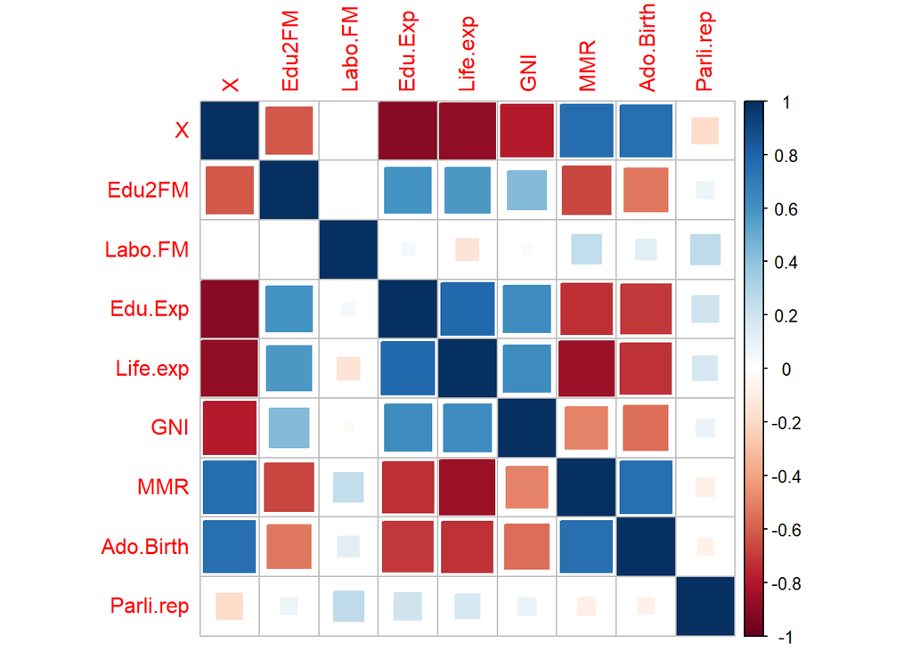

```r
cor_matrix <- cor(human_)
corrplot(cor_matrix, method = "square")
```

Note the lack of strong correlations of Representation of women in the parliament (Parli.rep) and the labour force(Labo.FM) with other variables. This will come up again in the following sections.

## Principal Component Analysis

```r
pca_unscaled <- prcomp(human_)

summary(pca_unscaled)
```

```
## Importance of components:
##                              PC1      PC2   PC3   PC4   PC5   PC6   PC7    PC8
## Standard deviation     1.854e+04 186.5901 26.22 18.72 10.95 3.137 1.078 0.1888
## Proportion of Variance 9.999e-01   0.0001  0.00  0.00  0.00 0.000 0.000 0.0000
## Cumulative Proportion  9.999e-01   1.0000  1.00  1.00  1.00 1.000 1.000 1.0000
##                           PC9
## Standard deviation     0.1591
## Proportion of Variance 0.0000
## Cumulative Proportion  1.0000
```

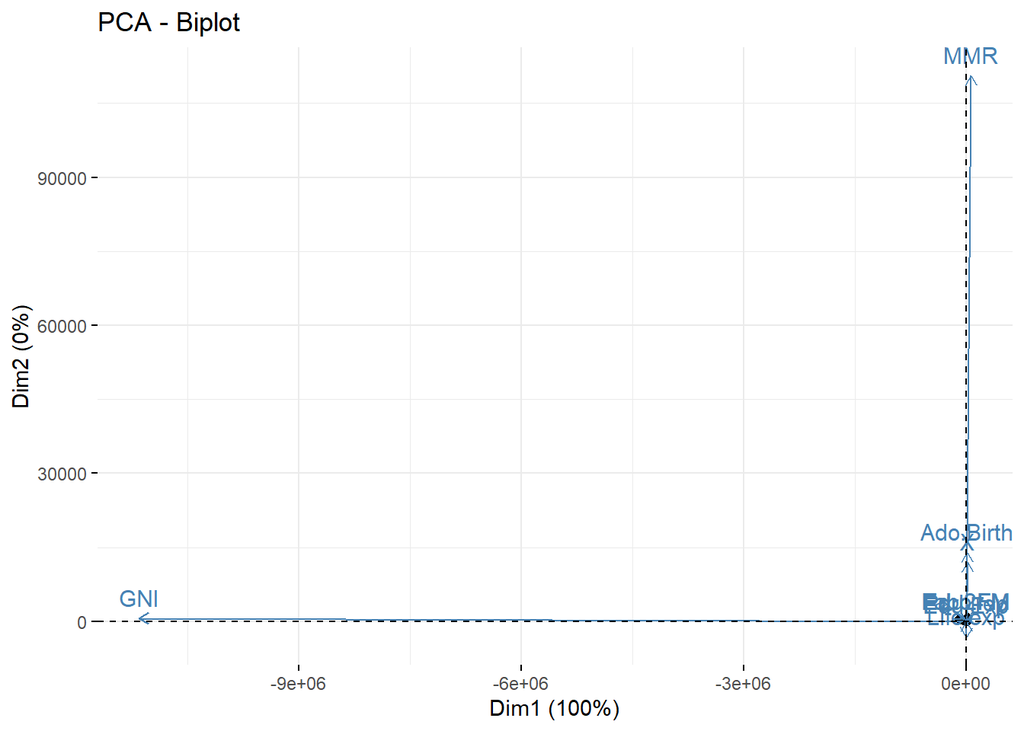

```r
fviz_pca_biplot(pca_unscaled,
                label="var", choices = 1:2)
```

Standardizing the dataset:

```r
human_std <- scale(human_)
```

Running a PCA on the scaled data:

```r
pca_scaled <- prcomp(human_std)


summary(pca_scaled)
```

```
## Importance of components:
##                           PC1    PC2     PC3     PC4     PC5    PC6     PC7
## Standard deviation     2.2770 1.1437 0.87751 0.79700 0.66196 0.5482 0.46456
## Proportion of Variance 0.5761 0.1453 0.08556 0.07058 0.04869 0.0334 0.02398
## Cumulative Proportion  0.5761 0.7214 0.80698 0.87756 0.92624 0.9596 0.98362
##                            PC8     PC9
## Standard deviation     0.32938 0.19731
## Proportion of Variance 0.01205 0.00433
## Cumulative Proportion  0.99567 1.00000
```

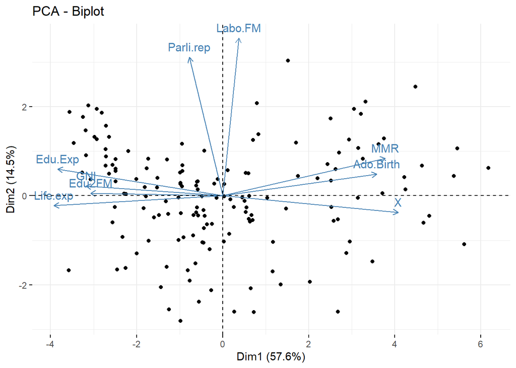

```r
fviz_pca_biplot(pca_scaled,
                label="var", choices = 1:2)
```

There are some obvious differences between the results of a PCA between the original and standardized data:

- PC1 explains 100% of the variations within the original dataset, but for the scaled dataset, PC1 explains nearly 58% of variations and PC2 explains nearly 15% of the variations.
- Maternal Mortality Ratio (MMR) and Per Capita Gross National Income (GNI) appear to be the most influential variabled in the unscaled dataset.
- In the scaled dataset, Life Expectancy, Expected years of Education, Per Capita Gross National Income, Proportion of Women with Higher Education, Proportion of women representation in the Parliament, Proportion of Women in the labour force, Maternal Mortality Ratio and Adolescent Births all make comparable comtribution to the variations.
- Taking into account the direction of the variables, the two datasets give us the following information:
  - **Unscaled dataset**: PC1 reflects the Gross National Income and PC2 reflects Maternal Mortality Ratio and Adolescent Births.
  - **Scaled dataset**: PC1 reflects indices of well-being, such as life expectancy, expected years of formal education, maternal mortality ratio, etc., while PC2 reflects the effect of these indices of well-being on servoces to the society, such as representation by women in the parliament and the labour force.
- The above observation in interesting especially in comparison to the correlation matrix, where neither women representation in the parliament or the labour force had very strong correlations with other factors. The PCA of the scaled dataset does show these variables to be directed in a different direction than most other variables.

## Multiple Correspondence Analysis

Reading the data:

```r
tea <- read.csv("https://raw.githubusercontent.com/KimmoVehkalahti/Helsinki-Open-Data-Science/master/datasets/tea.csv", stringsAsFactors = TRUE)
```

MCA:

```r
# Performing an MCA on the whole dataset displayed an error so I decided to go with the columns selected in the exercise set.

keep_columns <- c("Tea", "How", "how", "sugar", "where", "lunch")
tea_time <- tea %>% dplyr::select(keep_columns)
```

```r
mca <- MCA(tea_time, graph = FALSE)
summary(mca)
```

```
##
## Call:
## MCA(X = tea_time, graph = FALSE)
##
##
## Eigenvalues
##                        Dim.1   Dim.2   Dim.3   Dim.4   Dim.5   Dim.6   Dim.7
## Variance               0.279   0.261   0.219   0.189   0.177   0.156   0.144
## % of var.             15.238  14.232  11.964  10.333   9.667   8.519   7.841
## Cumulative % of var.  15.238  29.471  41.435  51.768  61.434  69.953  77.794
##                        Dim.8   Dim.9  Dim.10  Dim.11
## Variance               0.141   0.117   0.087   0.062
## % of var.              7.705   6.392   4.724   3.385
## Cumulative % of var.  85.500  91.891  96.615 100.000
##
## Individuals (the 10 first)
##                       Dim.1    ctr   cos2    Dim.2    ctr   cos2    Dim.3
## 1                  | -0.298  0.106  0.086 | -0.328  0.137  0.105 | -0.327
## 2                  | -0.237  0.067  0.036 | -0.136  0.024  0.012 | -0.695
## 3                  | -0.369  0.162  0.231 | -0.300  0.115  0.153 | -0.202
## 4                  | -0.530  0.335  0.460 | -0.318  0.129  0.166 |  0.211
## 5                  | -0.369  0.162  0.231 | -0.300  0.115  0.153 | -0.202
## 6                  | -0.369  0.162  0.231 | -0.300  0.115  0.153 | -0.202
## 7                  | -0.369  0.162  0.231 | -0.300  0.115  0.153 | -0.202
## 8                  | -0.237  0.067  0.036 | -0.136  0.024  0.012 | -0.695
## 9                  |  0.143  0.024  0.012 |  0.871  0.969  0.435 | -0.067
## 10                 |  0.476  0.271  0.140 |  0.687  0.604  0.291 | -0.650
##                       ctr   cos2
## 1                   0.163  0.104 |
## 2                   0.735  0.314 |
## 3                   0.062  0.069 |
## 4                   0.068  0.073 |
## 5                   0.062  0.069 |
## 6                   0.062  0.069 |
## 7                   0.062  0.069 |
## 8                   0.735  0.314 |
## 9                   0.007  0.003 |
## 10                  0.643  0.261 |
##
## Categories (the 10 first)
```

[output cut: 16 more lines]

```
## lemon                3.226 |   1.329  14.771   0.218   8.081 |
## milk                 2.422 |   0.013   0.003   0.000   0.116 |
## other                5.534 |  -2.524  14.526   0.197  -7.676 |
## tea bag             -6.941 |  -0.065   0.183   0.006  -1.287 |
## tea bag+unpackaged  11.956 |   0.019   0.009   0.000   0.226 |
## unpackaged          -6.482 |   0.257   0.602   0.009   1.640 |
##
## Categorical variables (eta2)
##                      Dim.1 Dim.2 Dim.3
## Tea                | 0.126 0.108 0.410 |
## How                | 0.076 0.190 0.394 |
## how                | 0.708 0.522 0.010 |
## sugar              | 0.065 0.001 0.336 |
## where              | 0.702 0.681 0.055 |
## lunch              | 0.000 0.064 0.111 |
```

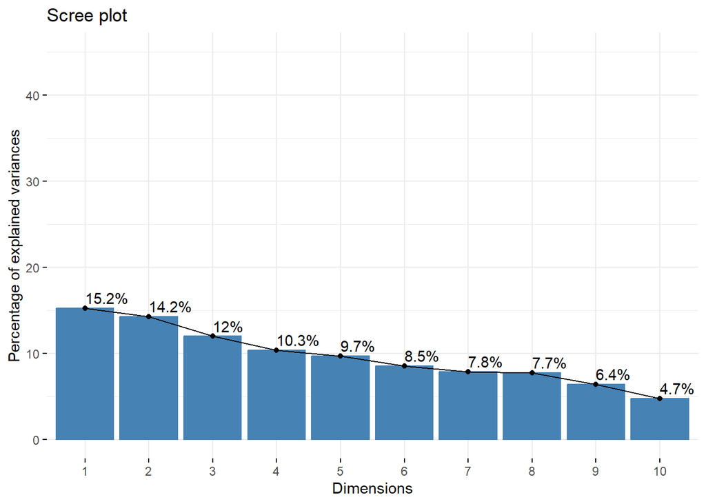

```r
fviz_screeplot(mca, addlabels = TRUE, ylim = c(0, 45))
```

Here we can see that Dimensions 1 and 2 explain about 15 and 14% of the variances in the data

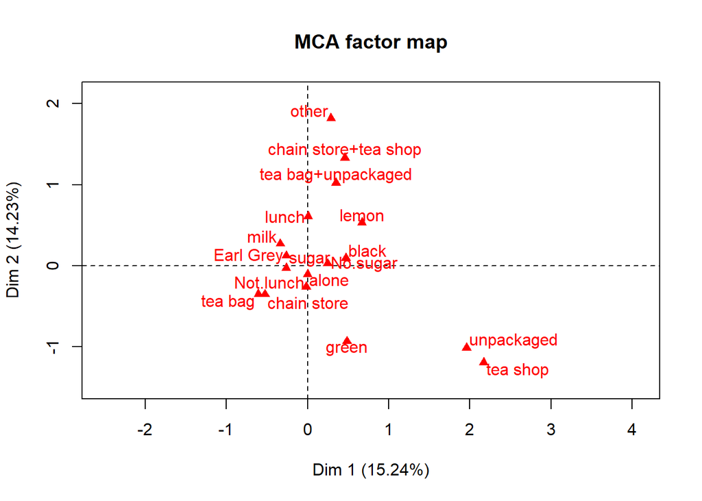

```r
plot(mca, invisible=c("ind"), graph.type = "classic")
```

The variables “unpackaged” and “tea shop” are quite separate from the rest of the variables, and most closely correlated with Component 1. Variables “tea bag + unpackaged”, “store + tea shop” and “others” appear most correlated with Component 2.